# RPU 2014 en chiffres

# tableau mensuel provisoire = jours consolidés + 6 derniers jours

# période équivalente en 2014

voir la fonction *mutation* dans new_fonction.R

# Demande du 5/2/2015

Dans la continuité de notre échange ce matin, pouvez-vous nous adresser : - le nombre de passages pour chaque établissement, avec le total pour chaque territoire de santé, et le total régional - pour chaque jour - du 1er au 31 janvier 2013 - du 1er au 31 janvier 2014 - du 1er au 31 janvier 2015

Sous format Excel s’il vous plait.

Selon la charge que cela représente, un retour pour le vendredi 13 février est-il envisageable?

Si vous avez par ailleurs d’autres éléments que vous jugez utiles ou pertinents, n’hésitez pas à me les communiquer. Je reste disponible pour en discuter.

```r
# load("../RPU_2013/rpu2013d0112.Rda") # d1
# load("rpu2014d0112_c.Rda") # d14
# load("d01_provisoire.Rda") # d01.p

load(paste0(path,"../RPU_2013/rpu2013d0112.Rda")) # d1
# load("rpu2014d0112_c.Rda") # d14
load(paste0(path, "d01_provisoire.Rda")) # d01.p

j2013 <-d1[as.Date(d1$ENTREE) < "2013-02-01",]
j2014 <-d14[as.Date(d14$ENTREE) < "2014-02-01",]
j2015 <- d01.p[as.Date(d01.p$ENTREE) < "2015-02-01",]
# ajout d'une colonne TERRITOIRE
j2013 <- create.col.territoire(j2013)
j2014 <- create.col.territoire(j2014)
j2015 <- create.col.territoire(j2015)

# total par territoire et par an
tot2013 <- tapply(as.Date(j2013$ENTREE), j2013$TERRITOIRE, length)
tot2014 <- tapply(as.Date(j2014$ENTREE), j2014$TERRITOIRE, length)
tot2015 <- tapply(as.Date(j2015$ENTREE), j2015$TERRITOIRE, length)
tot <- rbind(tot2013, tot2014, tot2015)
tot <- cbind(tot, apply(tot, 1, sum)) # ajout col total ligne
colnames(tot)[5] <- "Total"
nb_SU <- rbind(length(levels(j2013$FINESS)), length(levels(factor(j2014$FINESS))), length(levels(factor(j2015$FINESS))))
tot <- cbind(tot, nb_SU)
colnames(tot)[6] <- "Nb de SU"
tot
```

```
##           T1    T2   T3    T4 Total Nb de SU
## tot2013 3983  5514 9146  8215 26858       12
## tot2014 6422  4384 8818  9613 29237       12
## tot2015 7384 12781 9498 10842 40505       15
```

```r
# sauvegarde
write.csv(tot, file = "../../Analyse/ARS/total_par_territoires.csv")


# passages par jour et par établissement
f2013 <- tapply(as.Date(j2013$ENTREE), list(as.Date(j2013$ENTREE), j2013$FINESS), length)
f2014 <- tapply(as.Date(j2014$ENTREE), list(as.Date(j2014$ENTREE), factor(j2014$FINESS)), length)
f2015 <- tapply(as.Date(j2015$ENTREE), list(as.Date(j2015$ENTREE), factor(j2015$FINESS)), length)


# enregistrement au format csv
write.csv(f2013, file = "../../Analyse/ARS/RPU_janvier_2013.xls")
write.csv(f2014, file = "../../Analyse/ARS/RPU_janvier_2014.xls")
write.csv(f2015, file = "../../Analyse/ARS/RPU_janvier_2015.xls")
```

## Extension au tracé de courbes

On crée un dataframe à 4 colonnes:

- V1: date calendaire
- V2: nombre de RPU
- V3: date sous forme de n° du jour de l’année
- V4: moyenne mobile sur 7 jours

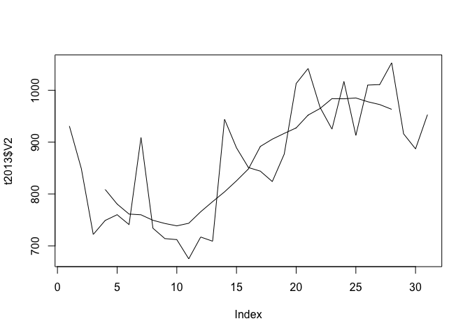

```r
library(lubridate)
library(xts)

# janvier 2013
t <- tapply(as.Date(j2013$ENTREE), as.Date(j2013$ENTREE), length)
t2013 <- as.data.frame(cbind(names(t), as.numeric(t)), stringsAsFactors = FALSE)
t2013$V1 <- as.Date(t2013$V1) # col. date
t2013$V2 <- as.numeric(t2013$V2) # nb de RPU
t2013$V3 <- yday(t2013$V1) # date du jour en n° du jour dans l'année
t2013$V4 <- rollmean(t2013$V2, 7, fill = NA) # moyenne mobile

plot(t2013$V2, type="l")
lines(t2013$V3, t2013$V4) # moyenne mobile
```